# Risk Factor Analysis

## Outcome Variable

**Outcome Variable:** ever_wasted

## Predictor Variables

**Intervention Variable:** brthmon

**Adjustment Set:**

unadjusted

## Stratifying Variables

The analysis was stratified on these variable(s):

- agecat
- studyid
- country

## Data Summary

| agecat | studyid | country | brthmon | ever_wasted | n_cell | n |
| --- | --- | --- | --- | --- | --- | --- |
| 0-24 months | CMC-V-BCS-2002 | INDIA | 1 | 0 | 17 | 373 |
| 0-24 months | CMC-V-BCS-2002 | INDIA | 1 | 1 | 17 | 373 |
| 0-24 months | CMC-V-BCS-2002 | INDIA | 2 | 0 | 8 | 373 |
| 0-24 months | CMC-V-BCS-2002 | INDIA | 2 | 1 | 8 | 373 |
| 0-24 months | CMC-V-BCS-2002 | INDIA | 3 | 0 | 14 | 373 |
| 0-24 months | CMC-V-BCS-2002 | INDIA | 3 | 1 | 17 | 373 |
| 0-24 months | CMC-V-BCS-2002 | INDIA | 4 | 0 | 21 | 373 |
| 0-24 months | CMC-V-BCS-2002 | INDIA | 4 | 1 | 23 | 373 |
| 0-24 months | CMC-V-BCS-2002 | INDIA | 5 | 0 | 14 | 373 |
| 0-24 months | CMC-V-BCS-2002 | INDIA | 5 | 1 | 22 | 373 |
| 0-24 months | CMC-V-BCS-2002 | INDIA | 6 | 0 | 12 | 373 |
| 0-24 months | CMC-V-BCS-2002 | INDIA | 6 | 1 | 25 | 373 |
| 0-24 months | CMC-V-BCS-2002 | INDIA | 7 | 0 | 21 | 373 |
| 0-24 months | CMC-V-BCS-2002 | INDIA | 7 | 1 | 18 | 373 |
| 0-24 months | CMC-V-BCS-2002 | INDIA | 8 | 0 | 2 | 373 |
| 0-24 months | CMC-V-BCS-2002 | INDIA | 8 | 1 | 16 | 373 |
| 0-24 months | CMC-V-BCS-2002 | INDIA | 9 | 0 | 8 | 373 |
| 0-24 months | CMC-V-BCS-2002 | INDIA | 9 | 1 | 13 | 373 |
| 0-24 months | CMC-V-BCS-2002 | INDIA | 10 | 0 | 9 | 373 |
| 0-24 months | CMC-V-BCS-2002 | INDIA | 10 | 1 | 20 | 373 |
| 0-24 months | CMC-V-BCS-2002 | INDIA | 11 | 0 | 13 | 373 |
| 0-24 months | CMC-V-BCS-2002 | INDIA | 11 | 1 | 30 | 373 |
| 0-24 months | CMC-V-BCS-2002 | INDIA | 12 | 0 | 6 | 373 |
| 0-24 months | CMC-V-BCS-2002 | INDIA | 12 | 1 | 19 | 373 |
| 0-24 months | CMIN | BANGLADESH | 1 | 0 | 18 | 272 |
| 0-24 months | CMIN | BANGLADESH | 1 | 1 | 10 | 272 |
| 0-24 months | CMIN | BANGLADESH | 2 | 0 | 15 | 272 |
| 0-24 months | CMIN | BANGLADESH | 2 | 1 | 12 | 272 |
| 0-24 months | CMIN | BANGLADESH | 3 | 0 | 9 | 272 |
| 0-24 months | CMIN | BANGLADESH | 3 | 1 | 11 | 272 |

[output cut: 1890 more lines]

The following strata were considered:

- agecat: 0-24 months, studyid: CMC-V-BCS-2002, country: INDIA
- agecat: 0-24 months, studyid: CMIN, country: BANGLADESH
- agecat: 0-24 months, studyid: CONTENT, country: PERU
- agecat: 0-24 months, studyid: EE, country: PAKISTAN
- agecat: 0-24 months, studyid: GMS-Nepal, country: NEPAL
- agecat: 0-24 months, studyid: Guatemala BSC, country: GUATEMALA
- agecat: 0-24 months, studyid: iLiNS-Zinc, country: BURKINA FASO
- agecat: 0-24 months, studyid: IRC, country: INDIA
- agecat: 0-24 months, studyid: JiVitA-3, country: BANGLADESH
- agecat: 0-24 months, studyid: JiVitA-4, country: BANGLADESH
- agecat: 0-24 months, studyid: Keneba, country: GAMBIA
- agecat: 0-24 months, studyid: LCNI-5, country: MALAWI
- agecat: 0-24 months, studyid: MAL-ED, country: BANGLADESH
- agecat: 0-24 months, studyid: MAL-ED, country: BRAZIL
- agecat: 0-24 months, studyid: MAL-ED, country: INDIA
- agecat: 0-24 months, studyid: MAL-ED, country: NEPAL
- agecat: 0-24 months, studyid: MAL-ED, country: PERU
- agecat: 0-24 months, studyid: MAL-ED, country: SOUTH AFRICA
- agecat: 0-24 months, studyid: MAL-ED, country: TANZANIA, UNITED REPUBLIC OF
- agecat: 0-24 months, studyid: NIH-Birth, country: BANGLADESH
- agecat: 0-24 months, studyid: PROBIT, country: BELARUS
- agecat: 0-24 months, studyid: PROVIDE, country: BANGLADESH
- agecat: 0-24 months, studyid: ResPak, country: PAKISTAN
- agecat: 0-24 months, studyid: SAS-CompFeed, country: INDIA
- agecat: 0-24 months, studyid: SAS-FoodSuppl, country: INDIA
- agecat: 0-24 months, studyid: TanzaniaChild2, country: TANZANIA, UNITED REPUBLIC OF
- agecat: 0-24 months, studyid: ZVITAMBO, country: ZIMBABWE
- agecat: 0-6 months, studyid: CMC-V-BCS-2002, country: INDIA
- agecat: 0-6 months, studyid: CMIN, country: BANGLADESH
- agecat: 0-6 months, studyid: CONTENT, country: PERU
- agecat: 0-6 months, studyid: EE, country: PAKISTAN
- agecat: 0-6 months, studyid: GMS-Nepal, country: NEPAL
- agecat: 0-6 months, studyid: Guatemala BSC, country: GUATEMALA
- agecat: 0-6 months, studyid: IRC, country: INDIA
- agecat: 0-6 months, studyid: JiVitA-3, country: BANGLADESH
- agecat: 0-6 months, studyid: JiVitA-4, country: BANGLADESH
- agecat: 0-6 months, studyid: Keneba, country: GAMBIA
- agecat: 0-6 months, studyid: LCNI-5, country: MALAWI
- agecat: 0-6 months, studyid: MAL-ED, country: BANGLADESH
- agecat: 0-6 months, studyid: MAL-ED, country: BRAZIL
- agecat: 0-6 months, studyid: MAL-ED, country: INDIA
- agecat: 0-6 months, studyid: MAL-ED, country: NEPAL
- agecat: 0-6 months, studyid: MAL-ED, country: PERU
- agecat: 0-6 months, studyid: MAL-ED, country: SOUTH AFRICA
- agecat: 0-6 months, studyid: MAL-ED, country: TANZANIA, UNITED REPUBLIC OF
- agecat: 0-6 months, studyid: NIH-Birth, country: BANGLADESH
- agecat: 0-6 months, studyid: PROBIT, country: BELARUS
- agecat: 0-6 months, studyid: PROVIDE, country: BANGLADESH
- agecat: 0-6 months, studyid: ResPak, country: PAKISTAN
- agecat: 0-6 months, studyid: SAS-CompFeed, country: INDIA
- agecat: 0-6 months, studyid: SAS-FoodSuppl, country: INDIA
- agecat: 0-6 months, studyid: TanzaniaChild2, country: TANZANIA, UNITED REPUBLIC OF
- agecat: 0-6 months, studyid: ZVITAMBO, country: ZIMBABWE
- agecat: 6-24 months, studyid: CMC-V-BCS-2002, country: INDIA
- agecat: 6-24 months, studyid: CMIN, country: BANGLADESH
- agecat: 6-24 months, studyid: CONTENT, country: PERU
- agecat: 6-24 months, studyid: EE, country: PAKISTAN
- agecat: 6-24 months, studyid: GMS-Nepal, country: NEPAL
- agecat: 6-24 months, studyid: Guatemala BSC, country: GUATEMALA
- agecat: 6-24 months, studyid: iLiNS-Zinc, country: BURKINA FASO
- agecat: 6-24 months, studyid: IRC, country: INDIA
- agecat: 6-24 months, studyid: JiVitA-3, country: BANGLADESH
- agecat: 6-24 months, studyid: JiVitA-4, country: BANGLADESH
- agecat: 6-24 months, studyid: Keneba, country: GAMBIA
- agecat: 6-24 months, studyid: LCNI-5, country: MALAWI
- agecat: 6-24 months, studyid: MAL-ED, country: BANGLADESH
- agecat: 6-24 months, studyid: MAL-ED, country: BRAZIL
- agecat: 6-24 months, studyid: MAL-ED, country: INDIA
- agecat: 6-24 months, studyid: MAL-ED, country: NEPAL
- agecat: 6-24 months, studyid: MAL-ED, country: PERU
- agecat: 6-24 months, studyid: MAL-ED, country: SOUTH AFRICA
- agecat: 6-24 months, studyid: MAL-ED, country: TANZANIA, UNITED REPUBLIC OF
- agecat: 6-24 months, studyid: NIH-Birth, country: BANGLADESH
- agecat: 6-24 months, studyid: PROBIT, country: BELARUS
- agecat: 6-24 months, studyid: PROVIDE, country: BANGLADESH
- agecat: 6-24 months, studyid: ResPak, country: PAKISTAN
- agecat: 6-24 months, studyid: SAS-CompFeed, country: INDIA
- agecat: 6-24 months, studyid: SAS-FoodSuppl, country: INDIA
- agecat: 6-24 months, studyid: TanzaniaChild2, country: TANZANIA, UNITED REPUBLIC OF
- agecat: 6-24 months, studyid: ZVITAMBO, country: ZIMBABWE

### Dropped Strata

Some strata were dropped due to rare outcomes:

- agecat: 0-24 months, studyid: CMC-V-BCS-2002, country: INDIA
- agecat: 0-24 months, studyid: CONTENT, country: PERU
- agecat: 0-24 months, studyid: EE, country: PAKISTAN
- agecat: 0-24 months, studyid: GMS-Nepal, country: NEPAL
- agecat: 0-24 months, studyid: Guatemala BSC, country: GUATEMALA
- agecat: 0-24 months, studyid: JiVitA-4, country: BANGLADESH
- agecat: 0-24 months, studyid: LCNI-5, country: MALAWI
- agecat: 0-24 months, studyid: MAL-ED, country: BANGLADESH
- agecat: 0-24 months, studyid: MAL-ED, country: BRAZIL
- agecat: 0-24 months, studyid: MAL-ED, country: INDIA
- agecat: 0-24 months, studyid: MAL-ED, country: NEPAL
- agecat: 0-24 months, studyid: MAL-ED, country: PERU
- agecat: 0-24 months, studyid: MAL-ED, country: SOUTH AFRICA
- agecat: 0-24 months, studyid: MAL-ED, country: TANZANIA, UNITED REPUBLIC OF
- agecat: 0-24 months, studyid: ResPak, country: PAKISTAN
- agecat: 0-24 months, studyid: SAS-FoodSuppl, country: INDIA
- agecat: 0-6 months, studyid: CMIN, country: BANGLADESH
- agecat: 0-6 months, studyid: CONTENT, country: PERU
- agecat: 0-6 months, studyid: EE, country: PAKISTAN
- agecat: 0-6 months, studyid: GMS-Nepal, country: NEPAL
- agecat: 0-6 months, studyid: Guatemala BSC, country: GUATEMALA
- agecat: 0-6 months, studyid: JiVitA-4, country: BANGLADESH
- agecat: 0-6 months, studyid: LCNI-5, country: MALAWI
- agecat: 0-6 months, studyid: MAL-ED, country: BANGLADESH
- agecat: 0-6 months, studyid: MAL-ED, country: BRAZIL
- agecat: 0-6 months, studyid: MAL-ED, country: INDIA
- agecat: 0-6 months, studyid: MAL-ED, country: NEPAL
- agecat: 0-6 months, studyid: MAL-ED, country: PERU
- agecat: 0-6 months, studyid: MAL-ED, country: SOUTH AFRICA
- agecat: 0-6 months, studyid: MAL-ED, country: TANZANIA, UNITED REPUBLIC OF
- agecat: 0-6 months, studyid: PROVIDE, country: BANGLADESH
- agecat: 0-6 months, studyid: ResPak, country: PAKISTAN
- agecat: 0-6 months, studyid: SAS-FoodSuppl, country: INDIA
- agecat: 6-24 months, studyid: CMC-V-BCS-2002, country: INDIA
- agecat: 6-24 months, studyid: CMIN, country: BANGLADESH
- agecat: 6-24 months, studyid: CONTENT, country: PERU
- agecat: 6-24 months, studyid: EE, country: PAKISTAN
- agecat: 6-24 months, studyid: GMS-Nepal, country: NEPAL
- agecat: 6-24 months, studyid: Guatemala BSC, country: GUATEMALA
- agecat: 6-24 months, studyid: JiVitA-4, country: BANGLADESH
- agecat: 6-24 months, studyid: LCNI-5, country: MALAWI
- agecat: 6-24 months, studyid: MAL-ED, country: BANGLADESH
- agecat: 6-24 months, studyid: MAL-ED, country: BRAZIL
- agecat: 6-24 months, studyid: MAL-ED, country: INDIA
- agecat: 6-24 months, studyid: MAL-ED, country: NEPAL
- agecat: 6-24 months, studyid: MAL-ED, country: PERU
- agecat: 6-24 months, studyid: MAL-ED, country: SOUTH AFRICA
- agecat: 6-24 months, studyid: MAL-ED, country: TANZANIA, UNITED REPUBLIC OF
- agecat: 6-24 months, studyid: PROVIDE, country: BANGLADESH
- agecat: 6-24 months, studyid: ResPak, country: PAKISTAN
- agecat: 6-24 months, studyid: SAS-FoodSuppl, country: INDIA

## Methods Detail

We're interested in the causal parameters $E[Y_a]$ for all values of $a \in \mathcal{A}$. These parameters represent the mean outcome if, possibly contrary to fact, we intervened to set all units to have $A=a$. Under the randomization and positivity assumptions, these are identified by the statistical parameters $\psi_a=E_W[E_{Y|A,W}(Y|A=a,W)]$. In addition, we're interested in the mean of $Y$, $E[Y]$ under no intervention (the observed mean). We will estimate these parameters by using SuperLearner to fit the relevant likelihood factors -- $E_{Y|A,W}(Y|A=a,W)$ and $p(A=a|W)$, and then updating our likelihood fit using a joint TMLE.

For unadjusted analyses ($W=\{\}$), initial likelihoods were estimated using Lrnr_glm to estimate the simple $E(Y|A)$ and Lrnr_mean to estimate $p(A)$. For adjusted analyses, a small library containing Lrnr_glmnet, Lrnr_xgboost, and Lrnr_mean was used.

Having estimated these parameters, we will then use the delta method to estimate relative risks and attributable risks relative to a prespecified baseline level of $A$.

# Results Detail

## Results Plots

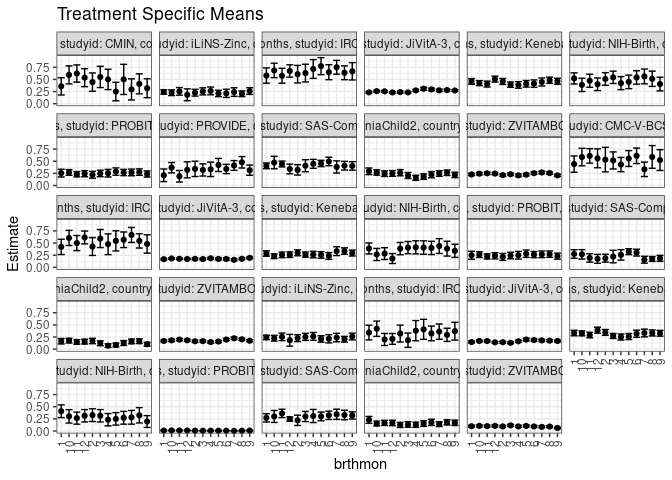

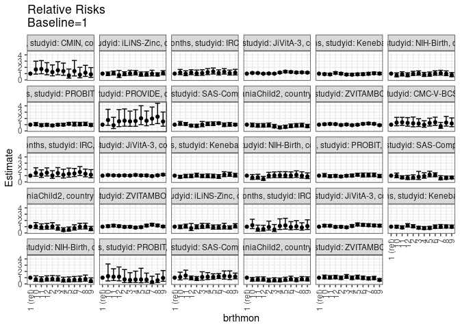

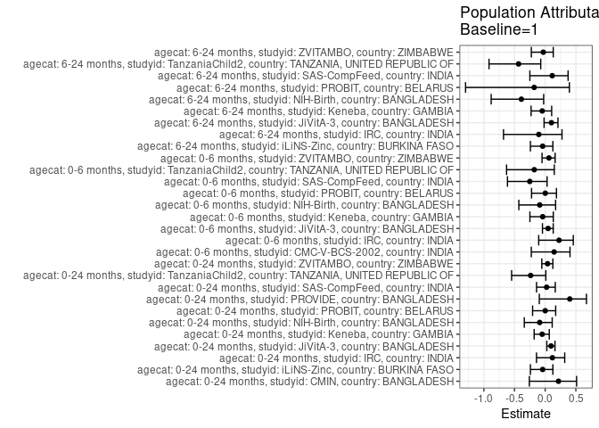

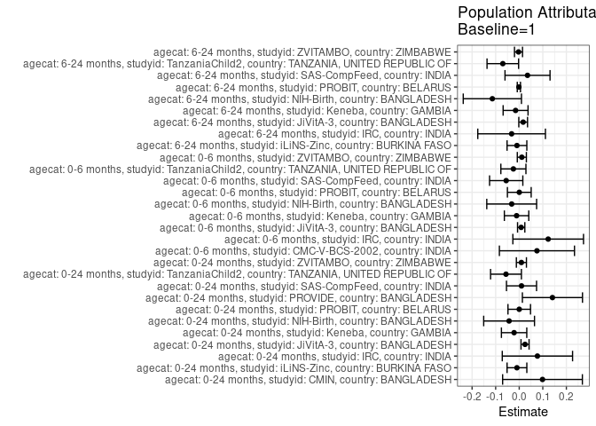

## Results Table

### Parameter: TSM

| agecat | studyid | country | intervention_level | baseline_level | estimate | ci_lower | ci_upper |
| --- | --- | --- | --- | --- | --- | --- | --- |
| 0-24 months | CMIN | BANGLADESH | 1 | NA | 0.3571429 | 0.1793366 | 0.5349491 |
| 0-24 months | CMIN | BANGLADESH | 2 | NA | 0.4444444 | 0.2566691 | 0.6322198 |
| 0-24 months | CMIN | BANGLADESH | 3 | NA | 0.5500000 | 0.3315659 | 0.7684341 |
| 0-24 months | CMIN | BANGLADESH | 4 | NA | 0.5000000 | 0.2906820 | 0.7093180 |
| 0-24 months | CMIN | BANGLADESH | 5 | NA | 0.2500000 | 0.0598775 | 0.4401225 |
| 0-24 months | CMIN | BANGLADESH | 6 | NA | 0.5000000 | 0.1895312 | 0.8104688 |
| 0-24 months | CMIN | BANGLADESH | 7 | NA | 0.2941176 | 0.0771224 | 0.5111129 |
| 0-24 months | CMIN | BANGLADESH | 8 | NA | 0.4090909 | 0.2032618 | 0.6149200 |
| 0-24 months | CMIN | BANGLADESH | 9 | NA | 0.3181818 | 0.1231935 | 0.5131701 |
| 0-24 months | CMIN | BANGLADESH | 10 | NA | 0.5925926 | 0.4069154 | 0.7782698 |
| 0-24 months | CMIN | BANGLADESH | 11 | NA | 0.6206897 | 0.4437670 | 0.7976123 |
| 0-24 months | CMIN | BANGLADESH | 12 | NA | 0.5357143 | 0.3506476 | 0.7207809 |
| 0-24 months | iLiNS-Zinc | BURKINA FASO | 1 | NA | 0.2414861 | 0.1966775 | 0.2862946 |
| 0-24 months | iLiNS-Zinc | BURKINA FASO | 2 | NA | 0.2265193 | 0.1563997 | 0.2966390 |
| 0-24 months | iLiNS-Zinc | BURKINA FASO | 3 | NA | 0.2538071 | 0.1810169 | 0.3265973 |
| 0-24 months | iLiNS-Zinc | BURKINA FASO | 4 | NA | 0.2631579 | 0.1834057 | 0.3429101 |
| 0-24 months | iLiNS-Zinc | BURKINA FASO | 5 | NA | 0.2110092 | 0.1452220 | 0.2767964 |
| 0-24 months | iLiNS-Zinc | BURKINA FASO | 6 | NA | 0.2135417 | 0.1290500 | 0.2980333 |
| 0-24 months | iLiNS-Zinc | BURKINA FASO | 7 | NA | 0.2397959 | 0.1522804 | 0.3273114 |
| 0-24 months | iLiNS-Zinc | BURKINA FASO | 8 | NA | 0.2046205 | 0.1460089 | 0.2632320 |
| 0-24 months | iLiNS-Zinc | BURKINA FASO | 9 | NA | 0.2603406 | 0.1912506 | 0.3294306 |
| 0-24 months | iLiNS-Zinc | BURKINA FASO | 10 | NA | 0.2258065 | 0.1670389 | 0.2845740 |
| 0-24 months | iLiNS-Zinc | BURKINA FASO | 11 | NA | 0.2536443 | 0.1759522 | 0.3313365 |
| 0-24 months | iLiNS-Zinc | BURKINA FASO | 12 | NA | 0.1838006 | 0.0622195 | 0.3053817 |
| 0-24 months | IRC | INDIA | 1 | NA | 0.5789474 | 0.4217757 | 0.7361191 |
| 0-24 months | IRC | INDIA | 2 | NA | 0.6071429 | 0.4260246 | 0.7882611 |
| 0-24 months | IRC | INDIA | 3 | NA | 0.6296296 | 0.4472580 | 0.8120012 |
| 0-24 months | IRC | INDIA | 4 | NA | 0.7142857 | 0.5208348 | 0.9077366 |
| 0-24 months | IRC | INDIA | 5 | NA | 0.7727273 | 0.5973983 | 0.9480563 |
| 0-24 months | IRC | INDIA | 6 | NA | 0.6486486 | 0.4946372 | 0.8026601 |

[output cut: 318 more lines]

### Parameter: E(Y)

| agecat | studyid | country | intervention_level | baseline_level | estimate | ci_lower | ci_upper |
| --- | --- | --- | --- | --- | --- | --- | --- |
| 0-24 months | CMIN | BANGLADESH | NA | NA | 0.4558824 | 0.3965849 | 0.5151798 |
| 0-24 months | iLiNS-Zinc | BURKINA FASO | NA | NA | 0.2317820 | 0.2038933 | 0.2596707 |
| 0-24 months | IRC | INDIA | NA | NA | 0.6560976 | 0.6100625 | 0.7021326 |
| 0-24 months | JiVitA-3 | BANGLADESH | NA | NA | 0.2580131 | 0.2515484 | 0.2644777 |
| 0-24 months | Keneba | GAMBIA | NA | NA | 0.4376712 | 0.4196742 | 0.4556682 |
| 0-24 months | NIH-Birth | BANGLADESH | NA | NA | 0.4775641 | 0.4383415 | 0.5167867 |
| 0-24 months | PROBIT | BELARUS | NA | NA | 0.2554148 | 0.1971257 | 0.3137039 |
| 0-24 months | PROVIDE | BANGLADESH | NA | NA | 0.3514286 | 0.3160364 | 0.3868207 |
| 0-24 months | SAS-CompFeed | INDIA | NA | NA | 0.4150694 | 0.3581204 | 0.4720184 |
| 0-24 months | TanzaniaChild2 | TANZANIA, UNITED REPUBLIC OF | NA | NA | 0.2362270 | 0.2192156 | 0.2532385 |
| 0-24 months | ZVITAMBO | ZIMBABWE | NA | NA | 0.2366987 | 0.2296439 | 0.2437535 |
| 0-6 months | CMC-V-BCS-2002 | INDIA | NA | NA | 0.5163043 | 0.4651769 | 0.5674318 |
| 0-6 months | IRC | INDIA | NA | NA | 0.5439024 | 0.4956326 | 0.5921723 |
| 0-6 months | JiVitA-3 | BANGLADESH | NA | NA | 0.1761793 | 0.1705546 | 0.1818041 |
| 0-6 months | Keneba | GAMBIA | NA | NA | 0.2733171 | 0.2557239 | 0.2909103 |
| 0-6 months | NIH-Birth | BANGLADESH | NA | NA | 0.3569132 | 0.3192325 | 0.3945938 |
| 0-6 months | PROBIT | BELARUS | NA | NA | 0.2500148 | 0.1915461 | 0.3084835 |
| 0-6 months | SAS-CompFeed | INDIA | NA | NA | 0.2199336 | 0.1753445 | 0.2645227 |
| 0-6 months | TanzaniaChild2 | TANZANIA, UNITED REPUBLIC OF | NA | NA | 0.1389816 | 0.1251275 | 0.1528358 |
| 0-6 months | ZVITAMBO | ZIMBABWE | NA | NA | 0.1811160 | 0.1747027 | 0.1875293 |
| 6-24 months | iLiNS-Zinc | BURKINA FASO | NA | NA | 0.2317820 | 0.2038933 | 0.2596707 |
| 6-24 months | IRC | INDIA | NA | NA | 0.3097561 | 0.2649438 | 0.3545684 |
| 6-24 months | JiVitA-3 | BANGLADESH | NA | NA | 0.1640074 | 0.1578946 | 0.1701202 |
| 6-24 months | Keneba | GAMBIA | NA | NA | 0.3166545 | 0.2992274 | 0.3340815 |
| 6-24 months | NIH-Birth | BANGLADESH | NA | NA | 0.2933579 | 0.2549918 | 0.3317241 |
| 6-24 months | PROBIT | BELARUS | NA | NA | 0.0083745 | 0.0044130 | 0.0123360 |
| 6-24 months | SAS-CompFeed | INDIA | NA | NA | 0.3059755 | 0.2638053 | 0.3481458 |
| 6-24 months | TanzaniaChild2 | TANZANIA, UNITED REPUBLIC OF | NA | NA | 0.1605550 | 0.1445335 | 0.1765765 |
| 6-24 months | ZVITAMBO | ZIMBABWE | NA | NA | 0.0958853 | 0.0903360 | 0.1014347 |

### Parameter: RR

| agecat | studyid | country | intervention_level | baseline_level | estimate | ci_lower | ci_upper |
| --- | --- | --- | --- | --- | --- | --- | --- |
| 0-24 months | CMIN | BANGLADESH | 1 | 1 | 1.0000000 | 1.0000000 | 1.0000000 |
| 0-24 months | CMIN | BANGLADESH | 2 | 1 | 1.2444444 | 0.6477334 | 2.3908634 |
| 0-24 months | CMIN | BANGLADESH | 3 | 1 | 1.5400000 | 0.8145828 | 2.9114289 |
| 0-24 months | CMIN | BANGLADESH | 4 | 1 | 1.4000000 | 0.7305167 | 2.6830324 |
| 0-24 months | CMIN | BANGLADESH | 5 | 1 | 0.7000000 | 0.2820603 | 1.7372172 |
| 0-24 months | CMIN | BANGLADESH | 6 | 1 | 1.4000000 | 0.6316574 | 3.1029480 |
| 0-24 months | CMIN | BANGLADESH | 7 | 1 | 0.8235294 | 0.3381706 | 2.0054989 |
| 0-24 months | CMIN | BANGLADESH | 8 | 1 | 1.1454545 | 0.5643848 | 2.3247722 |
| 0-24 months | CMIN | BANGLADESH | 9 | 1 | 0.8909091 | 0.4045109 | 1.9621698 |
| 0-24 months | CMIN | BANGLADESH | 10 | 1 | 1.6592593 | 0.9213837 | 2.9880508 |
| 0-24 months | CMIN | BANGLADESH | 11 | 1 | 1.7379310 | 0.9792319 | 3.0844627 |
| 0-24 months | CMIN | BANGLADESH | 12 | 1 | 1.5000000 | 0.8183151 | 2.7495522 |
| 0-24 months | iLiNS-Zinc | BURKINA FASO | 1 | 1 | 1.0000000 | 1.0000000 | 1.0000000 |
| 0-24 months | iLiNS-Zinc | BURKINA FASO | 2 | 1 | 0.9380224 | 0.6777875 | 1.2981739 |
| 0-24 months | iLiNS-Zinc | BURKINA FASO | 3 | 1 | 1.0510217 | 0.7210423 | 1.5320137 |
| 0-24 months | iLiNS-Zinc | BURKINA FASO | 4 | 1 | 1.0897436 | 0.7893412 | 1.5044711 |
| 0-24 months | iLiNS-Zinc | BURKINA FASO | 5 | 1 | 0.8737944 | 0.6012040 | 1.2699793 |
| 0-24 months | iLiNS-Zinc | BURKINA FASO | 6 | 1 | 0.8842815 | 0.6093875 | 1.2831798 |
| 0-24 months | iLiNS-Zinc | BURKINA FASO | 7 | 1 | 0.9930010 | 0.6398446 | 1.5410791 |
| 0-24 months | iLiNS-Zinc | BURKINA FASO | 8 | 1 | 0.8473386 | 0.6300392 | 1.1395841 |
| 0-24 months | iLiNS-Zinc | BURKINA FASO | 9 | 1 | 1.0780772 | 0.7892836 | 1.4725386 |
| 0-24 months | iLiNS-Zinc | BURKINA FASO | 10 | 1 | 0.9350703 | 0.6936391 | 1.2605352 |
| 0-24 months | iLiNS-Zinc | BURKINA FASO | 11 | 1 | 1.0503476 | 0.7850355 | 1.4053252 |
| 0-24 months | iLiNS-Zinc | BURKINA FASO | 12 | 1 | 0.7611231 | 0.3830690 | 1.5122821 |
| 0-24 months | IRC | INDIA | 1 | 1 | 1.0000000 | 1.0000000 | 1.0000000 |
| 0-24 months | IRC | INDIA | 2 | 1 | 1.0487013 | 0.7006149 | 1.5697274 |
| 0-24 months | IRC | INDIA | 3 | 1 | 1.0875421 | 0.7312026 | 1.6175378 |
| 0-24 months | IRC | INDIA | 4 | 1 | 1.2337662 | 0.8408016 | 1.8103904 |
| 0-24 months | IRC | INDIA | 5 | 1 | 1.3347107 | 0.9369768 | 1.9012773 |
| 0-24 months | IRC | INDIA | 6 | 1 | 1.1203931 | 0.7811561 | 1.6069525 |

[output cut: 318 more lines]

### Parameter: PAR

| agecat | studyid | country | intervention_level | baseline_level | estimate | ci_lower | ci_upper |
| --- | --- | --- | --- | --- | --- | --- | --- |
| 0-24 months | CMIN | BANGLADESH | 1 | NA | 0.0987395 | -0.0704417 | 0.2679207 |
| 0-24 months | iLiNS-Zinc | BURKINA FASO | 1 | NA | -0.0097041 | -0.0516561 | 0.0322479 |
| 0-24 months | IRC | INDIA | 1 | NA | 0.0771502 | -0.0719909 | 0.2262913 |
| 0-24 months | JiVitA-3 | BANGLADESH | 1 | NA | 0.0246263 | 0.0075206 | 0.0417321 |
| 0-24 months | Keneba | GAMBIA | 1 | NA | -0.0217882 | -0.0755884 | 0.0320119 |
| 0-24 months | NIH-Birth | BANGLADESH | 1 | NA | -0.0429838 | -0.1507574 | 0.0647897 |
| 0-24 months | PROBIT | BELARUS | 1 | NA | 0.0000542 | -0.0477598 | 0.0478683 |
| 0-24 months | PROVIDE | BANGLADESH | 1 | NA | 0.1409023 | 0.0134202 | 0.2683843 |
| 0-24 months | SAS-CompFeed | INDIA | 1 | NA | 0.0096640 | -0.0541265 | 0.0734545 |
| 0-24 months | TanzaniaChild2 | TANZANIA, UNITED REPUBLIC OF | 1 | NA | -0.0561706 | -0.1215586 | 0.0092173 |
| 0-24 months | ZVITAMBO | ZIMBABWE | 1 | NA | 0.0091894 | -0.0121398 | 0.0305186 |
| 0-6 months | CMC-V-BCS-2002 | INDIA | 1 | NA | 0.0751279 | -0.0841952 | 0.2344509 |
| 0-6 months | IRC | INDIA | 1 | NA | 0.1228498 | -0.0269962 | 0.2726958 |
| 0-6 months | JiVitA-3 | BANGLADESH | 1 | NA | 0.0083078 | -0.0071482 | 0.0237638 |
| 0-6 months | Keneba | GAMBIA | 1 | NA | -0.0112983 | -0.0631097 | 0.0405132 |
| 0-6 months | NIH-Birth | BANGLADESH | 1 | NA | -0.0319757 | -0.1377100 | 0.0737586 |
| 0-6 months | PROBIT | BELARUS | 1 | NA | 0.0002587 | -0.0501355 | 0.0506529 |
| 0-6 months | SAS-CompFeed | INDIA | 1 | NA | -0.0552958 | -0.1258548 | 0.0152632 |
| 0-6 months | TanzaniaChild2 | TANZANIA, UNITED REPUBLIC OF | 1 | NA | -0.0247611 | -0.0779595 | 0.0284374 |
| 0-6 months | ZVITAMBO | ZIMBABWE | 1 | NA | 0.0110633 | -0.0081936 | 0.0303202 |
| 6-24 months | iLiNS-Zinc | BURKINA FASO | 1 | NA | -0.0097041 | -0.0516561 | 0.0322479 |
| 6-24 months | IRC | INDIA | 1 | NA | -0.0323492 | -0.1758358 | 0.1111375 |
| 6-24 months | JiVitA-3 | BANGLADESH | 1 | NA | 0.0166925 | -0.0018219 | 0.0352068 |
| 6-24 months | Keneba | GAMBIA | 1 | NA | -0.0154623 | -0.0683019 | 0.0373773 |
| 6-24 months | NIH-Birth | BANGLADESH | 1 | NA | -0.1140495 | -0.2375394 | 0.0094405 |
| 6-24 months | PROBIT | BELARUS | 1 | NA | -0.0015069 | -0.0083020 | 0.0052882 |
| 6-24 months | SAS-CompFeed | INDIA | 1 | NA | 0.0351422 | -0.0603771 | 0.1306614 |
| 6-24 months | TanzaniaChild2 | TANZANIA, UNITED REPUBLIC OF | 1 | NA | -0.0696608 | -0.1366064 | -0.0027153 |
| 6-24 months | ZVITAMBO | ZIMBABWE | 1 | NA | -0.0030779 | -0.0201167 | 0.0139609 |

### Parameter: PAF

| agecat | studyid | country | intervention_level | baseline_level | estimate | ci_lower | ci_upper |
| --- | --- | --- | --- | --- | --- | --- | --- |
| 0-24 months | CMIN | BANGLADESH | 1 | NA | 0.2165899 | -0.2586442 | 0.5123869 |
| 0-24 months | iLiNS-Zinc | BURKINA FASO | 1 | NA | -0.0418672 | -0.2409749 | 0.1252947 |
| 0-24 months | IRC | INDIA | 1 | NA | 0.1175895 | -0.1421481 | 0.3182598 |
| 0-24 months | JiVitA-3 | BANGLADESH | 1 | NA | 0.0954461 | 0.0265820 | 0.1594385 |
| 0-24 months | Keneba | GAMBIA | 1 | NA | -0.0497822 | -0.1802042 | 0.0662272 |
| 0-24 months | NIH-Birth | BANGLADESH | 1 | NA | -0.0900064 | -0.3408885 | 0.1139352 |
| 0-24 months | PROBIT | BELARUS | 1 | NA | 0.0002123 | -0.2056694 | 0.1709373 |
| 0-24 months | PROVIDE | BANGLADESH | 1 | NA | 0.4009414 | -0.0961744 | 0.6726149 |
| 0-24 months | SAS-CompFeed | INDIA | 1 | NA | 0.0232828 | -0.1411654 | 0.1640332 |
| 0-24 months | TanzaniaChild2 | TANZANIA, UNITED REPUBLIC OF | 1 | NA | -0.2377823 | -0.5478204 | 0.0101532 |
| 0-24 months | ZVITAMBO | ZIMBABWE | 1 | NA | 0.0388232 | -0.0556439 | 0.1248367 |
| 0-6 months | CMC-V-BCS-2002 | INDIA | 1 | NA | 0.1455108 | -0.2265497 | 0.4047108 |
| 0-6 months | IRC | INDIA | 1 | NA | 0.2258674 | -0.1059101 | 0.4581103 |
| 0-6 months | JiVitA-3 | BANGLADESH | 1 | NA | 0.0471555 | -0.0446461 | 0.1308897 |
| 0-6 months | Keneba | GAMBIA | 1 | NA | -0.0413376 | -0.2492489 | 0.1319712 |
| 0-6 months | NIH-Birth | BANGLADESH | 1 | NA | -0.0895896 | -0.4300627 | 0.1698228 |
| 0-6 months | PROBIT | BELARUS | 1 | NA | 0.0010347 | -0.2223460 | 0.1835932 |
| 0-6 months | SAS-CompFeed | INDIA | 1 | NA | -0.2514205 | -0.6153667 | 0.0305277 |
| 0-6 months | TanzaniaChild2 | TANZANIA, UNITED REPUBLIC OF | 1 | NA | -0.1781606 | -0.6300782 | 0.1484688 |
| 0-6 months | ZVITAMBO | ZIMBABWE | 1 | NA | 0.0610842 | -0.0514789 | 0.1615973 |
| 6-24 months | iLiNS-Zinc | BURKINA FASO | 1 | NA | -0.0418672 | -0.2409749 | 0.1252947 |
| 6-24 months | IRC | INDIA | 1 | NA | -0.1044343 | -0.6799327 | 0.2739143 |
| 6-24 months | JiVitA-3 | BANGLADESH | 1 | NA | 0.1017786 | -0.0185809 | 0.2079160 |
| 6-24 months | Keneba | GAMBIA | 1 | NA | -0.0488302 | -0.2297050 | 0.1054401 |
| 6-24 months | NIH-Birth | BANGLADESH | 1 | NA | -0.3887724 | -0.8811253 | -0.0252846 |
| 6-24 months | PROBIT | BELARUS | 1 | NA | -0.1799414 | -1.2986320 | 0.3943085 |
| 6-24 months | SAS-CompFeed | INDIA | 1 | NA | 0.1148529 | -0.2501475 | 0.3732857 |
| 6-24 months | TanzaniaChild2 | TANZANIA, UNITED REPUBLIC OF | 1 | NA | -0.4338751 | -0.9164352 | -0.0728241 |
| 6-24 months | ZVITAMBO | ZIMBABWE | 1 | NA | -0.0320998 | -0.2260053 | 0.1311376 |